# Programming Exercise 2: Logistic Regression

Kristi Angel

2/9/2020

## Introduction

In this exercise, we will implement logistic regression and apply it to two different datasets. All materials are derived from [Andrew Ng’s Machine Learning course](https://www.coursera.org/learn/machine-learning/programming/ixFof/logistic-regression) on Coursera.

## Files included in this exercise

- ex2.m - Octave/MATLAB script that steps you through the exercise ex2
- reg.m - Octave/MATLAB script for the later parts of the exercise
- ex2data1.txt - Training set for the first half of the exercise
- ex2data2.txt - Training set for the second half of the exercise
- submit.m - Submission script that sends your solutions to our servers
- mapFeature.m - Function to generate polynomial features
- plotDecisionBoundary.m - Function to plot classifier’s decision boundary
- [$\star$] plotData.m - Function to plot 2D classification data
- [$\star$] sigmoid.m - Sigmoid Function
- [$\star$] costFunction.m - Logistic Regression Cost Function
- [$\star$] predict.m - Logistic Regression Prediction Function
- [$\star$] costFunctionReg.m - Regularized Logistic Regression Cost

[$\star$] indicates files you will need to complete

## Logistic Regression

Here we build a logistic regression model to predict whether a student gets admitted into a university.

Suppose that an administrator of a university department wants to determine each applicant’s chance of admission based on their results on two exams. We have historical data from previous applicants that we can use as a training set for logistic regression. For each training example, we have the applicant’s scores on two exams and the admissions decision. The first two columns contains the exam scores and the third column contains the label.

We will build a classification model that estimates an applicant’s probability of admission based the scores from those two exams.

```r
training <- read_csv("../data/ex2/ex2data1.txt", col_names = FALSE)
colnames(training) <- c("exam1", "exam2", "admitted")
test <- read_csv("../data/ex2/ex2data2.txt", col_names = FALSE)
```

### Exploring the data

Before starting to implement any learning algorithm, it is always good to inspect and visualize the data if possible.

```r
summary(training)
```

```
##      exam1           exam2          admitted
##  Min.   :30.06   Min.   :30.60   Min.   :0.0
##  1st Qu.:50.92   1st Qu.:48.18   1st Qu.:0.0
##  Median :67.03   Median :67.68   Median :1.0
##  Mean   :65.64   Mean   :66.22   Mean   :0.6
##  3rd Qu.:80.21   3rd Qu.:79.36   3rd Qu.:1.0
##  Max.   :99.83   Max.   :98.87   Max.   :1.0
```

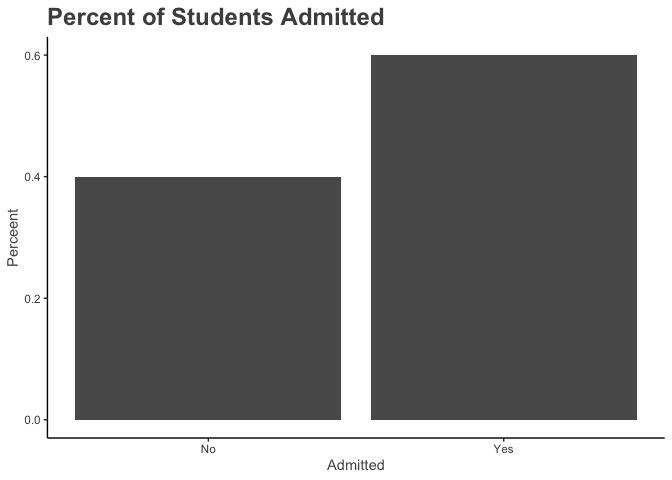

```r
theme <- theme_classic() +
            theme(plot.title = element_text(color = "gray30", size=18, face="bold"),
                  axis.title.x = element_text(color = "gray34"),
                  axis.title.y = element_text(color = "gray34"))
training %>%
  ggplot(aes(x = admitted)) +
    geom_bar(aes(y = (..count..) / sum(..count..))) +
    scale_x_continuous("Admitted", breaks = c(0, 1), labels = c("No", "Yes")) +
    theme +
    ggtitle("Percent of Students Admitted") +
    ylab("Perceent")
```

It appears the data set is not balanced with approximately 60% admitted and 40% not admitted.

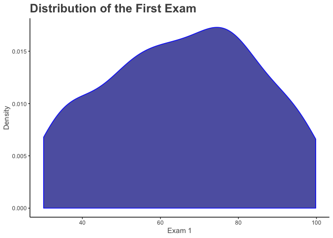

```r
training %>%
  ggplot(aes(x = exam1)) +
  geom_density(fill = "blue4", color = "blue1", alpha = 0.7) +
  theme +
  ggtitle("Distribution of the First Exam") +
  xlab("Exam 1") +
  ylab("Density")
```

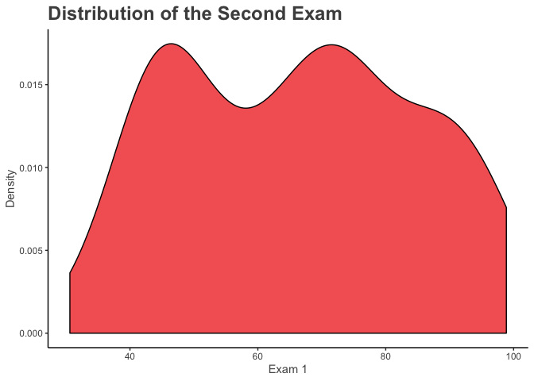

```r
training %>%
  ggplot(aes(x = exam2)) +
  geom_density(fill = "red2", alpha = 0.7) +
  theme +
  ggtitle("Distribution of the Second Exam") +
  xlab("Exam 1") +
  ylab("Density")
```

Neither distibution is Normally ditributed. The summary statistics and the interquartile ranges look similar for each exam. But when we visualize the data, we can see the second exam is bimodal. It looks like more students did better and worse, with fewer falling in the middle.

Let’s see how the two exams correlate with eachother and admittance.

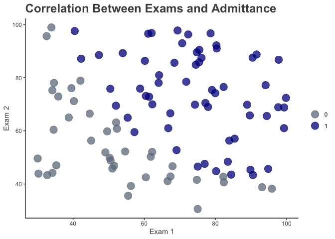

```r
training %>%
  ggplot(aes(x = exam1, y = exam2)) +
    geom_point(aes(color = as.factor(admitted),
                   fill = as.factor(admitted)),
                   size = 5,
                   alpha = 0.75) +
      scale_color_manual(values=c("lightsteelblue4", "blue4")) +
      theme +
  ggtitle("Correlation Between Exams and Admittance") +
  xlab("Exam 1") +
  ylab("Exam 2") +
  theme(legend.title = element_blank())
```

There is pretty clean seperation here between the two categories, admitted and not admitted. It appears the average needed to be roughly greater than 60 to pass but this doesn’t seem to be strictly true.

### Implementation

#### Warmup exercise: sigmoid function

Before you start with the actual cost function, recall that the logistic regression hypothesis is defined as:

$$h_\theta(x) = g(\theta ^ T X)$$

where function g is the sigmoid function. The sigmoid function is defined as:

$$g(z) = \frac{1}{1 + e ^ {-z}}$$
Your first step is to implement this function in sigmoid.m so it can be called by the rest of your program. When you are finished, try testing a few values by calling sigmoid(x) at the Octave/MATLAB command line. For large positive values of x, the sigmoid should be close to 1, while for large negative values, the sigmoid should be close to 0. Evaluating sigmoid(0) should give you exactly 0.5. Your code should also work with vectors and matrices. For a matrix, your function should perform the sigmoid function on every element.

You can submit your solution for grading by typing submit at the Octave/MATLAB command line. The submission script will prompt you for your login e-mail and submission token and ask you which files you want to submit. You can obtain a submission token from the web page for the assignment.

#### Cost function and gradient

Now you will implement the cost function and gradient for logistic regression. Complete the code in costFunction.m to return the cost and gradient.

Recall that the cost function in logistic regression is:

$$J(\theta) = \frac{1}{m}\sum_{i=1}^{m}[-y^{(i)}log(h_\theta(x^{(i)})) - (1 - y^{(i)})log(1 - h_\theta(x^{(i)}))]$$

and the gradient of the cost is a vector of the same length as θ where the jth element (for j = 0,1,…,n) is defined as follows:

$$\frac{\partial J(\theta)}{\partial \theta_j} = \frac{1}{m}\sum_{i=1}^{m}(h_\theta(x^{(i)}) - y^{(i)})x_j^{(i)}$$

Note that while this gradient looks identical to the linear regression gradient, the formula is actually different because linear and logistic regression have different definitions of $h_\theta(x)$.

Once you are done, ex2.m will call your costFunction using the initial parameters of $\theta$. You should see that the cost is about 0.693.

#### Learning parameters using fminunc

In the previous assignment, you found the optimal parameters of a linear regression model by implementing gradent descent. You wrote a cost function and calculated its gradient, then took a gradient descent step accordingly. This time, instead of taking gradient descent steps, you will use an Octave/MATLAB built-in function called fminunc.

Octave/MATLAB’s fminunc is an optimization solver that finds the minimum of an unconstrained2 function. For logistic regression, you want to optimize the cost function J($\theta$) with parameters $\theta$.

Concretely, you are going to use fminunc to find the best parameters θ for the logistic regression cost function, given a fixed dataset (of X and y values). You will pass to fminunc the following inputs:

- The initial values of the parameters we are trying to optimize.
- A function that, when given the training set and a particular $\theta$, computes the logistic regression cost and gradient with respect to $\theta$ for the dataset (X, y).

In ex2.m, we already have code written to call fminunc with the correct arguments.

Furthermore, we set the MaxIter option to 400, so that fminunc will run for at most 400 steps before it terminates.

To specify the actual function we are minimizing, we use a “short-hand” for specifying functions with the @(t) ( costFunction(t, X, y) ) . This creates a function, with argument t, which calls your costFunction. This allows us to wrap the costFunction for use with fminunc. If you have completed the costFunction correctly, fminunc will converge on the right optimization parameters and return the final values of the cost and $\theta$. Notice that by using fminunc, you did not have to write any loops yourself, or set a learning rate like you did for gradient descent. This is all done by fminunc: you only needed to provide a function calculating the cost and the gradient.

Once fminunc completes, ex2.m will call your costFunction function using the optimal parameters of $\theta$. You should see that the cost is about 0.203.

#### Evaluating logistic regression

After learning the parameters, you can use the model to predict whether a particular student will be admitted. For a student with an Exam 1 score of 45 and an Exam 2 score of 85, you should expect to see an admission probability of 0.776.

Another way to evaluate the quality of the parameters we have found is to see how well the learned model predicts on our training set. In this part, your task is to complete the code in predict.m. The predict function will produce “1” or “0” predictions given a dataset and a learned parameter vector $\theta$.

After you have completed the code in predict.m, the ex2.m script will proceed to report the training accuracy of your classifier by computing the percentage of examples it got correct.

## Regularized logistic regression

In this part of the exercise, you will implement regularized logistic regression to predict whether microchips from a fabrication plant passes quality assur- ance (QA). During QA, each microchip goes through various tests to ensure it is functioning correctly. Suppose you are the product manager of the factory and you have the test results for some microchips on two different tests. From these two tests, you would like to determine whether the microchips should be accepted or rejected. To help you make the decision, you have a dataset of test results on past microchips, from which you can build a logistic regression model.

You will use another script, ex2 reg.m to complete this portion of the exercise.

### Feature mapping

One way to fit the data better is to create more features from each data point. In the provided function mapFeature.m, we will map the features into all polynomial terms of x1 and x2 up to the sixth power.

As a result of this mapping, our vector of two features (the scores on two QA tests) has been transformed into a 28-dimensional vector. A logistic regression classifier trained on this higher-dimension feature vector will have a more complex decision boundary and will appear nonlinear when drawn in our 2-dimensional plot.

While the feature mapping allows us to build a more expressive classifier, it also more susceptible to overfitting. In the next parts of the exercise, you will implement regularized logistic regression to fit the data and also see for yourself how regularization can help combat the overfitting problem.

### Cost function and gradient

Now you will implement code to compute the cost function and gradient for regularized logistic regression. Complete the code in costFunctionReg.m to return the cost and gradient.

Recall that the regularized cost function in logistic regression is:

$$J(\theta) - \frac{1}{m}\sum_{i=1}^m[-y^{(i)}log(h_\theta(x^{(i)}))-(1 - y^{(i)})log(1 - h_{\theta}(x^{(i)}))] + \frac{\lambda}{2m}\sum_{j=1}^n\theta^2_j$$

Note that you should not regularize the parameter θ0. In Octave/MATLAB, recall that indexing starts from 1, hence, you should not be regularizing the theta(1) parameter (which corresponds to θ0) in the code. The gradient of the cost function is a vector where the jth element is defined as follows:

$$\frac{\partial J(\theta)}{\partial \theta_j} = \frac{1}{m}\sum_{i=1}^{m}(h_\theta(x^{(i)}) - y^{(i)})x_j^{(i)}\;\;\;\;\;\;\;\;for\:j = 0$$

$$\frac{\partial J(\theta)}{\partial \theta_j} = \left(\frac{1}{m}\sum_{i=1}^{m}(h_\theta(x^{(i)}) - y^{(i)})x_j^{(i)}\right) + \frac{\lambda}{m}\theta_j\;\;\;\;\;\;\;\;for\:j\ge1$$

Once you are done, ex2 reg.m will call your costFunctionReg function using the initial value of $\theta$ (initialized to all zeros). You should see that the cost is about 0.693.

#### Learning parameters using fminunc

Similar to the previous parts, you will use fminunc to learn the optimal parameters $\theta$. If you have completed the cost and gradient for regularized logistic regression (costFunctionReg.m) correctly, you should be able to step through the next part of ex2 reg.m to learn the parameters θ using fminunc.

### Plotting the decision boundary

To help you visualize the model learned by this classifier, we have provided the function plotDecisionBoundary.m which plots the (non-linear) decision boundary that separates the positive and negative examples. In plotDecisionBoundary.m, we plot the non-linear decision boundary by computing the classifier’s predictions on an evenly spaced grid and then and drew a contour plot of where the predictions change from y = 0 to y = 1.

### Optional exercises

In this part of the exercise, you will get to try out different regularization parameters for the dataset to understand how regularization prevents overfitting.